# Probability Distribution - Discrete

- Author: Diego Inácio
- GitHub: github.com/diegoinacio
- Notebook: distributions_discrete.ipynb

Brief overview of *discrete probability distributions*.

```python
%matplotlib inline
import matplotlib
import matplotlib.pyplot as plt

import numpy as np
import pandas as pd
```

```python
np.seterr(divide='ignore')
plt.rcParams['figure.figsize'] = (16, 8)
```

## Introduction

A **discrete probability distribution** is the probability distribution of a random variable with countable number of values. For example, list of real number or non-negative integers ($k = 1, 2, 3 ..$).. Thus, a **discrete random variable** is a random variable whose probability distribution is discrete.

The [probability mass function](https://en.wikipedia.org/wiki/Probability_mass_function) of a discrete random variable $X$ with $k$ occurrences can be expressed as:

$$ \large f(k)=Pr(X = k) $$

### Cumulative distribution functions

A **cumulative distribution function** calculates the probability of a random observation being less than or equal a certain value. It can be expressed as:

$$ \large F(k)=Pr(X \leq k)=\sum_{i}^{k}Pr(X = i) $$

## Uniform distribution

A **discrete uniform distribution** is characterized by [symmetry](https://en.wikipedia.org/wiki/Symmetric_probability_distribution) and finite number of values that are equally likely to be observed. In other words, every one of $\large n$ values has equal probability $\large\frac{1}{n}$ to occurs. It is convenient to represent its values generally by all integers $k$ in an interval $[a,b]$, so $a$ and $b$ are the main parameters of the distribution, expressed as:

$$ \large f(k;a,b)=Pr(X = k)=\frac{1}{b - a + 1} $$

```python
def uniformDistribution(k, a, b):
    den = b - a + 1
    return 1/den
```

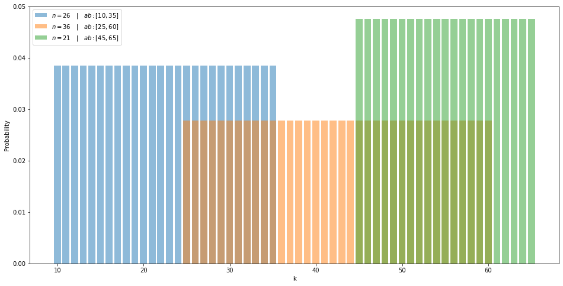

```python
ud = uniformDistribution

# Distribution A
a, b = 10, 35
RANGE = np.arange(a, b + 1)
n = RANGE.size

plt.bar(
    RANGE, [ud(k, a, b) for k in RANGE],
    alpha=0.5,
    label=f'$n={n} \\quad|\\quad ab:[{a},{b}]$'
)

# Distribution B
a, b = 25, 60
RANGE = np.arange(a, b + 1)
n = RANGE.size

plt.bar(
    RANGE, [ud(k, a, b) for k in RANGE],
    alpha=0.5,
    label=f'$n={n} \\quad|\\quad ab:[{a},{b}]$'
)

# Distribution C
a, b = 45, 65
RANGE = np.arange(a, b + 1)
n = RANGE.size

plt.bar(
    RANGE, [ud(k, a, b) for k in RANGE],
    alpha=0.5,
    label=f'$n={n} \\quad|\\quad ab:[{a},{b}]$'
)

# Visualization
plt.xlabel('k')
plt.ylabel('Probability')
plt.legend()
plt.show()
```

### Cumulative uniform distribution

The *cumulative uniform distribution* of the *discrete uniform distribution* can be expressed, for any $k \in [a,b]$, as:

$$ \large F(k;a,b)=Pr(X \leq k)=\frac{\lfloor{k}\rfloor - a + 1}{b - a + 1} $$

```python
def cumulativeUniformDistribution(k, a, b):
    k = np.floor(k)
    num = k - a + 1
    den = b - a + 1
    return num/den
```

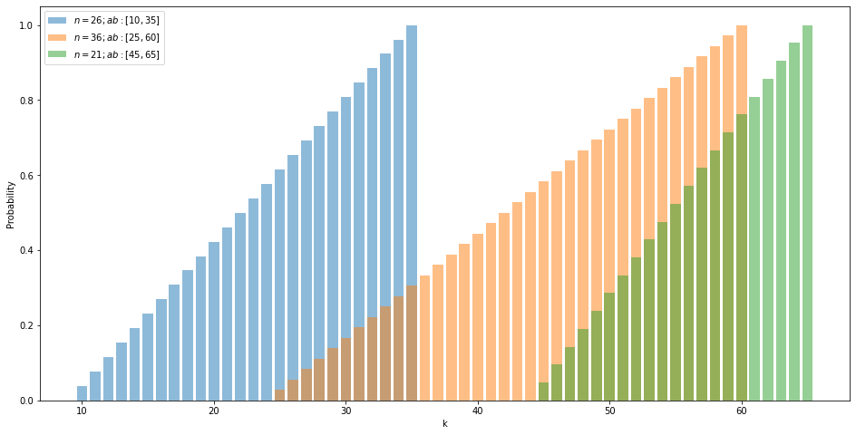

```python
cud = cumulativeUniformDistribution

# Cumulative distribution A
a, b = 10, 35
RANGE = np.arange(a, b + 1)
n = RANGE.size

plt.bar(
    RANGE, [cud(k, a, b) for k in RANGE],
    alpha=0.5,
    label=f'$n={n};ab:[{a},{b}]$'
)

# Cumulative distribution B
a, b = 25, 60
RANGE = np.arange(a, b + 1)
n = RANGE.size

plt.bar(
    RANGE, [cud(k, a, b) for k in RANGE],
    alpha=0.5,
    label=f'$n={n};ab:[{a},{b}]$'
)

# Cumulative distribution C
a, b = 45, 65
RANGE = np.arange(a, b + 1)
n = RANGE.size

plt.bar(
    RANGE, [cud(k, a, b) for k in RANGE],
    alpha=0.5,
    label=f'$n={n};ab:[{a},{b}]$'
)

# Visualization
plt.xlabel('k')
plt.ylabel('Probability')
plt.legend()
plt.show()
```

## Binomial distribution

A **discrete binomial distribution** provide the probability of getting exactly *k successes* in *n* independent [Bernoulli](https://en.wikipedia.org/wiki/Bernoulli_distribution) [trials](https://en.wikipedia.org/wiki/Bernoulli_trial). In other words, binomial distribution is a discrete probability distribution which expresses the probability of one set of two alternatives: success (with probability $p$) and failure (with probability $1 - p$).

$$ \large f(k;n,p)=Pr(X=k)={n \choose k}p^k (1-p)^{ n-k}=\frac{n!}{k!(n-k)!}p^k (1-p)^{ n-k} $$

where:

- ${n \choose k}$ is a **binomial coeficient**;
- $k$ is the number of successes;
- $n$ is the total number of trials;
- $p$ is the probability.

```python
def factorial(n):
    # Factorial of n
    if n <= 1:
        return 1
    return n*factorial(n - 1)

def binomial(k, n):
    # Binomial coefficient of n and k
    n_ = factorial(n)
    k_ = factorial(k)
    nk_ = factorial(n - k)
    return n_//(k_*nk_)

def binomialDistribution(k, n, p):
    # Binomial distribution
    B = binomial(k, n)
    return B*p**k*(1 - p)**(n - k)
```

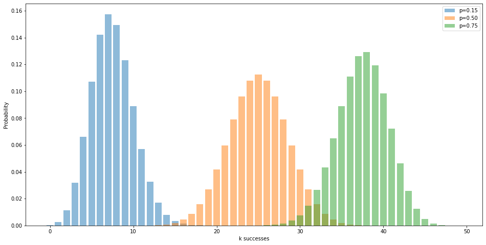

```python
bd = binomialDistribution

n = 50
RANGE = np.arange(n, dtype=np.uint64)

# Distributions A, B and C
plt.bar(RANGE, [bd(k, n, 0.15) for k in RANGE], alpha=0.5, label='p=0.15')
plt.bar(RANGE, [bd(k, n, 0.50) for k in RANGE], alpha=0.5, label='p=0.50')
plt.bar(RANGE, [bd(k, n, 0.75) for k in RANGE], alpha=0.5, label='p=0.75')

# Visualization
plt.xlabel('k successes')
plt.ylabel('Probability')
plt.legend()
plt.show()
```

### Cumulative binomial distribution

The *cumulative uniform distribution* of the *discrete binomial distribution* can be expressed as:

$$ \large F(k;n,p)=Pr(X \leq k)=\sum_{i=0}^{k}{n \choose i}p^i (1-p)^{n-i}=\sum_{i=0}^{k}\frac{n!}{i!(n-i)!}p^i (1-p)^{n-i} $$

```python
def cumulativeBinomialDistribution(k, n, p):
    # Cumulative binomial distribution function
    K = np.arange(k + 1)
    B = np.array([binomial(i, n) for i in K])
    return np.sum(B*p**K*(1 - p)**(n - K))
```

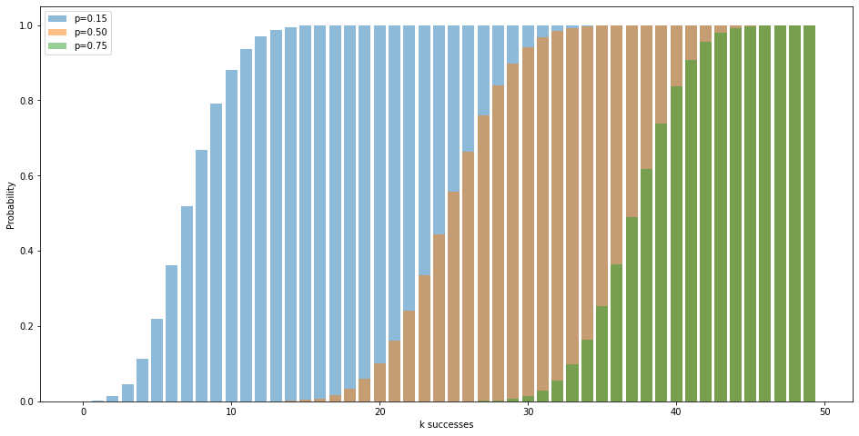

```python
cbd = cumulativeBinomialDistribution

n = 50
RANGE = np.arange(n, dtype=np.uint64)

# Cumulative distributions A, B and C
plt.bar(RANGE, [cbd(k, n, 0.15) for k in RANGE], alpha=0.5, label='p=0.15')
plt.bar(RANGE, [cbd(k, n, 0.50) for k in RANGE], alpha=0.5, label='p=0.50')
plt.bar(RANGE, [cbd(k, n, 0.75) for k in RANGE], alpha=0.5, label='p=0.75')

# Visualization
plt.xlabel('k successes')
plt.ylabel('Probability')
plt.legend()
plt.show()
```

## Poisson distribution

The **discrete poisson distribution** express the probability of a number of events occurring in a certain interval of time or space if these events occur independently of the last event.

$$ \large f(k;\lambda)=Pr(X=k)=\frac{\lambda^k e^{-\lambda}}{k!} $$

```python
def poissonDistribution(k, l):
    # Poisson distribution
    num = l**k*np.exp(-l)
    den = factorial(k)
    return num/den
```

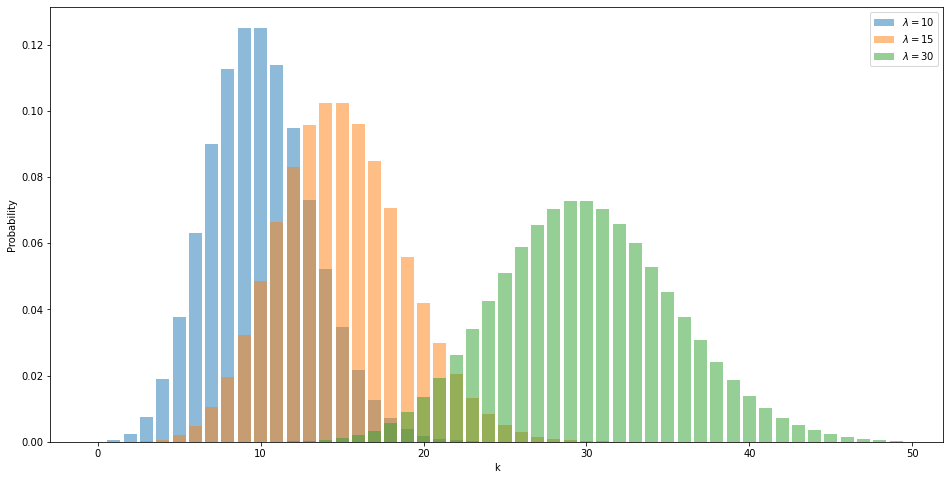

```python
pd = poissonDistribution

n = 50
RANGE = np.arange(n, dtype=np.uint64)

# Distributions A, B and C
plt.bar(RANGE, [pd(k, 10) for k in RANGE], alpha=0.5, label='$\lambda=10$')
plt.bar(RANGE, [pd(k, 15) for k in RANGE], alpha=0.5, label='$\lambda=15$')
plt.bar(RANGE, [pd(k, 30) for k in RANGE], alpha=0.5, label='$\lambda=30$')

# Visualization
plt.xlabel('k')
plt.ylabel('Probability')
plt.legend()
plt.show()
```

### Cumulative Poisson distribution

The *cumulative uniform distribution* of the *discrete Poisson distribution* can be expressed as:

$$ \large F(k;\lambda)=Pr(X \leq k)=\sum_{i=0}^{k}\frac{\lambda^i e^{-\lambda}}{i!} $$

```python
def cumulativePoissonDistribution(k, l):
    # Cumulative Poisson distribution function
    K = np.arange(k + 1)
    Li= np.array([l**i for i in K])
    I_ = np.array([factorial(i) for i in K])
    return np.sum(Li*np.exp(-l)/I_)
```

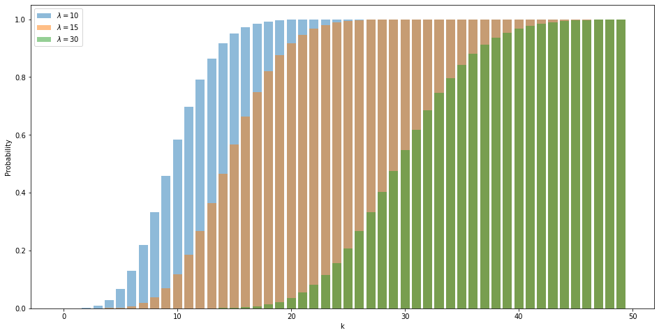

```python
cpd = cumulativePoissonDistribution

n = 50
RANGE = np.arange(n, dtype=np.uint64)

# Cumulative distributions A, B and C
plt.bar(RANGE, [cpd(k, 10) for k in RANGE], alpha=0.5, label='$\lambda=10$')
plt.bar(RANGE, [cpd(k, 15) for k in RANGE], alpha=0.5, label='$\lambda=15$')
plt.bar(RANGE, [cpd(k, 30) for k in RANGE], alpha=0.5, label='$\lambda=30$')

# Visualization
plt.xlabel('k')
plt.ylabel('Probability')
plt.legend()
plt.show()
```